# Solution

Statistics layer - Data Visualization - Part 5

### Exercise 1

What is the default geom associated with `stat_summary()`? How could you rewrite the previous plot to use that geom function instead of the stat function?

**Answer**

Previous plot:

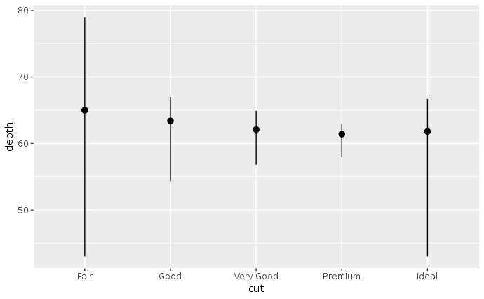

```r
ggplot(data = diamonds) +
  stat_summary(
    mapping = aes(x = cut, y = depth),
    fun.ymin = min,
    fun.ymax = max,
    fun.y = median
  )
```

The default geom for `stat_summary()` is `geom_pointrange()` (see the `stat`) argument.

But, the default stat for `geom_pointrange()` is `identity()`, so use `geom_pointrange(stat = "summary")`.

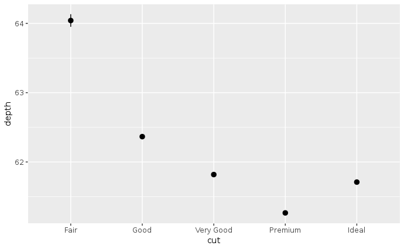

```r
ggplot(data = diamonds) +
  geom_pointrange(
    mapping = aes(x = cut, y = depth),
    stat = "summary",
  )
```

The default message says that `stat_summary()` uses the mean and sd to calculate the point, and range of the line. So lets use the previous values of `fun.ymin`, `fun.ymax`, and `fun.y`:

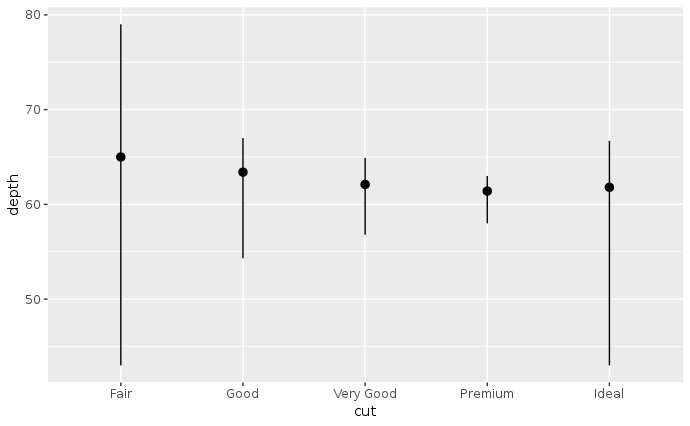

```r
ggplot(data = diamonds) +
  geom_pointrange(
    mapping = aes(x = cut, y = depth),
    stat = "summary",
    fun.ymin = min,
    fun.ymax = max,
    fun.y = median
  )
```

### Exercise 2

What does `geom_col()` do? How is it different to `geom_bar()`?

**Answer**

The geom_col() function has different default stat than geom_bar(). The default stat of geom_col() is stat_identity(), which leaves the data as is. The geom_col() function expects that the data contains x values and y values which represent the bar height.

The default stat of geom_bar() is stat_bin(). The geom_bar() function only expects an x variable. The stat, stat_bin(), preprocesses input data by counting the number of observations for each value of x. The y aesthetic uses the values of these counts.

For instance, we can “reproduce” the column chart from the notebook by `geom_col()`. It is slightly different since we are using a random generator:

```r
demo <- data.frame(X=c("a","b","c","d"),
           Y=sample(5:20, 4, replace=FALSE))
```

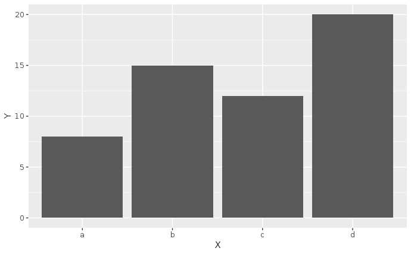

```r
ggplot(data = demo) +
  geom_col(mapping = aes(x = X, y = Y))
```

### Exercise 3

What variables does `stat_smooth()` compute? What parameters control its behavior?

**Answer**

The function `stat_smooth()` calculates the following statistics:

- `y`: predicted value
- `ymin`: lower value of the confidence interval
- `ymax`: upper value of the confidence interval
- `se`: standard error

> stat_smooth(mapping = NULL, data = NULL, geom = “smooth”,  
> position = “identity”, …, method = “auto”, formula = y ~ x,  
> se = TRUE, n = 80, span = 0.75, fullrange = FALSE, level = 0.95,  
> method.args = list(), na.rm = FALSE, show.legend = NA,  
> inherit.aes = TRUE)

### Exercise 4

What is the problem with this plot? How could you improve it?

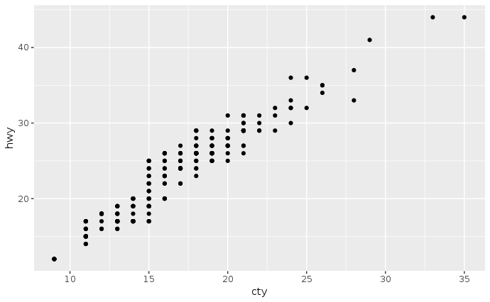

```r
ggplot(data = mpg, mapping = aes(x = cty, y = hwy)) +
  geom_point()
```

**Answer**

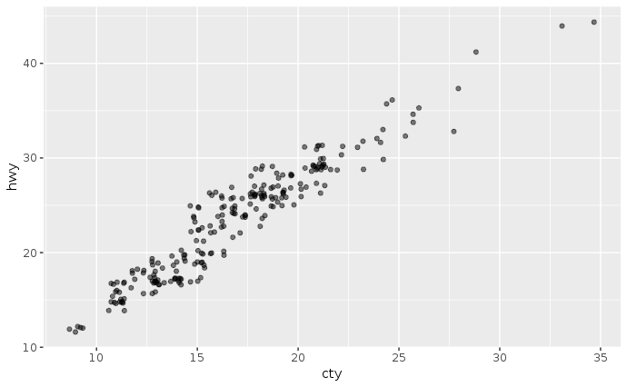

```r
ggplot(data = mpg, mapping = aes(x = cty, y = hwy)) +
  geom_point(position = "jitter", alpha = 1/2)
```

### Exercise 5

Use `position_jitter()` to modify the amount of jittering. What parameters in `geom_jitter()` control the amount of jittering?

**Answer**

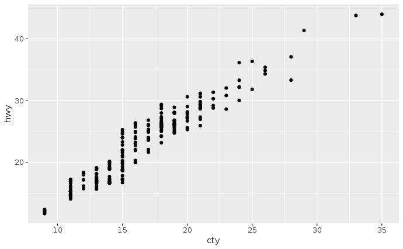

```r
ggplot(data = mpg, mapping = aes(x = cty, y = hwy)) +
  geom_point(position = position_jitter(width = 0))
```

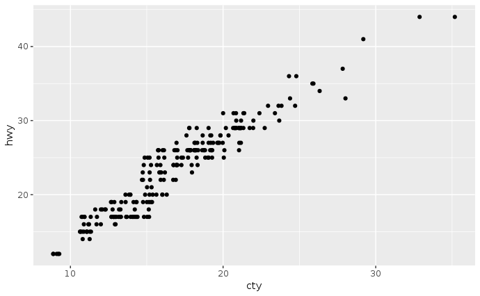

```r
ggplot(data = mpg, mapping = aes(x = cty, y = hwy)) +
  geom_point(position = position_jitter(height = 0))
```

### Exercise 6

Compare `geom_jitter()` with `geom_count()`.

**Answer**

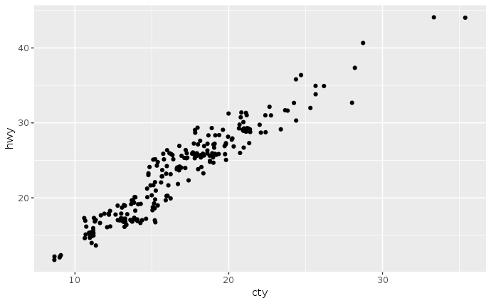

```r
ggplot(data = mpg, mapping = aes(x = cty, y = hwy)) +
  geom_jitter()
```

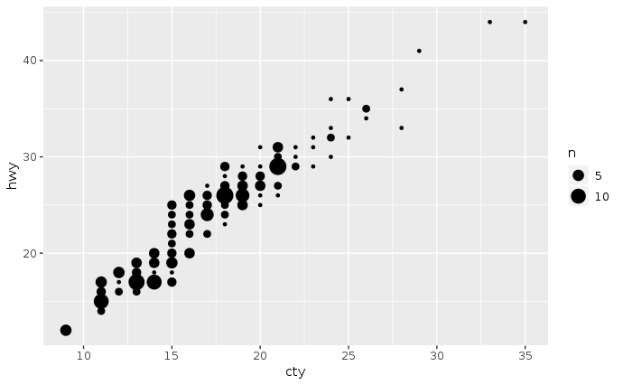

```r
ggplot(data = mpg, mapping = aes(x = cty, y = hwy)) +
  geom_count()
```

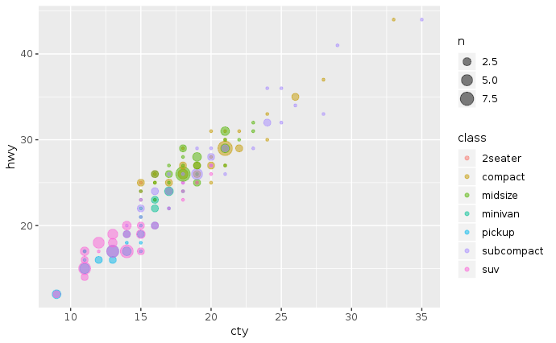

```r
ggplot(data = mpg, mapping = aes(x = cty, y = hwy, color = class)) +
  geom_count(alpha = 1/2)
```

### Exercise 7

We haven’t plotted a boxplot yet, check out the documentation for `geom_boxplot()` and look at some the examples. What’s the default position adjustment for `geom_boxplot()`? Create a visualization of the mpg dataset that demonstrates it.

**Answer**

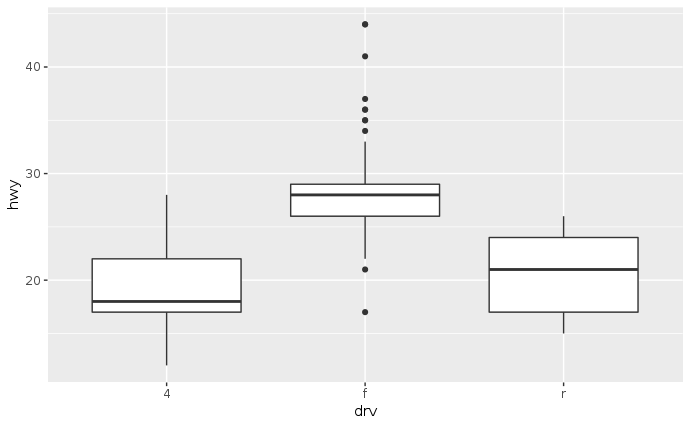

```r
ggplot(data = mpg, aes(x = drv, y = hwy)) +
  geom_boxplot()
```

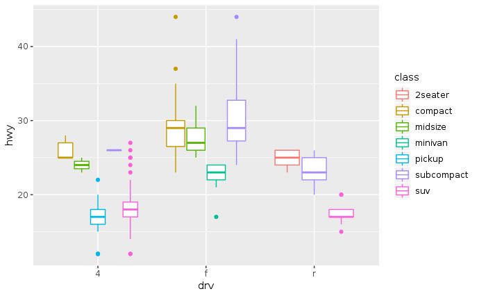

```r
ggplot(data = mpg, aes(x = drv, y = hwy, colour = class)) +
  geom_boxplot()
```